# Homework exercise 2

## Time Series

We will be analysing a trend stationary time series.

```r
library(astsa)
```

A **trend stationary** series is one that when the trend is removed  
it becomes stationary.  
We will be analysing one of the kind Mt=β0+β1t+et.  
That is, it has a inicial mean β0, a trend β1 and a white noise et. In this case et will be gaussian white noise.

The series will be created with the following parameters.  
**Sampling frequency**: monthly  
**Start date**: 01/2000  
**End date**: 08/2016  
**Length**: 200 months  
**β0**: 0  
**β1**: 0.1  
**var(et)**: 2

```r
set.seed(123)
B1<-0.1
length<-200
trend<-seq(0,length*B1,by=B1) #creates the trend part of the time series
var<-2
tsts <- ts(rnorm(length,mean=trend,sd=sqrt(var)),start=c(2000,1),frequency=12)
str(tsts)
```

```
##  Time-Series [1:200] from 2000 to 2017: -0.793 -0.226 2.404 0.4 0.583 ...
```

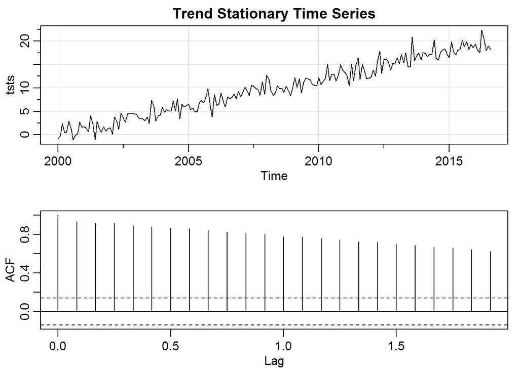

```r
par(mfrow = c(2,1))
tsplot(tsts,main = "Trend Stationary Time Series")
acf(tsts)
```

## Theoretical Analysis

**Theoretical values of the model**

**Expected Value**  
E(Mt) = E(β0+β1t+et) = β0+β1t = 0.1t

**Variance**  
var(Mt) = var(et) = 2

**Covariance**  
COV(Ms,Mt) = E[(Ms-E(Ms))(Mt-E(Mt))] =  
= E[(β0+β1s+es-β1s)(β0+β1t+et-β1t)] =  
= E[es*et] = var(et) = 2, s=t; 0, s!=t

**Autocorrelation Function**  
ACF(s,t) = 1, s=t; 0, s!=t.

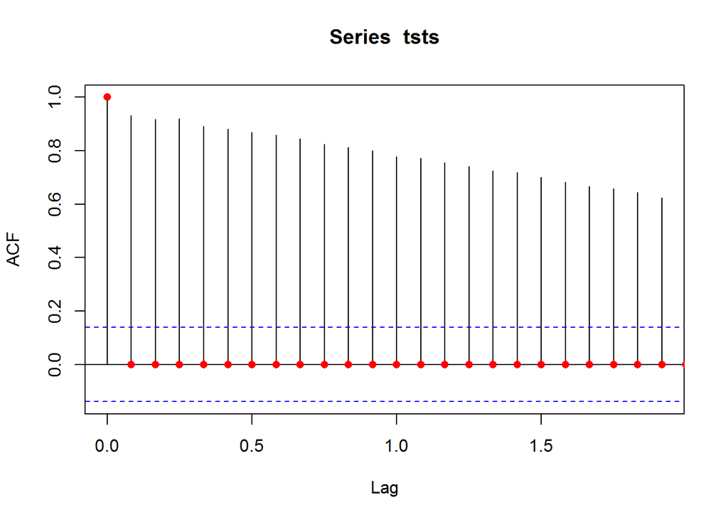

```r
acf(tsts)
points(x=seq(0,2,by=1/12),y=c(1,rep(0,24)),pch=16,col="red") #Values of model ACF
```

The sample ACF is completely different from that of the model(red dots).  
While we know the true ACF (that of the theoretical model) and the model  
to be trend stationary, the trend ofuscates that fact due to it making  
the series not stationary.

## Model Manipulation

We will try to extract more information from the model.

First lets compare the sample trend to the real known trend.

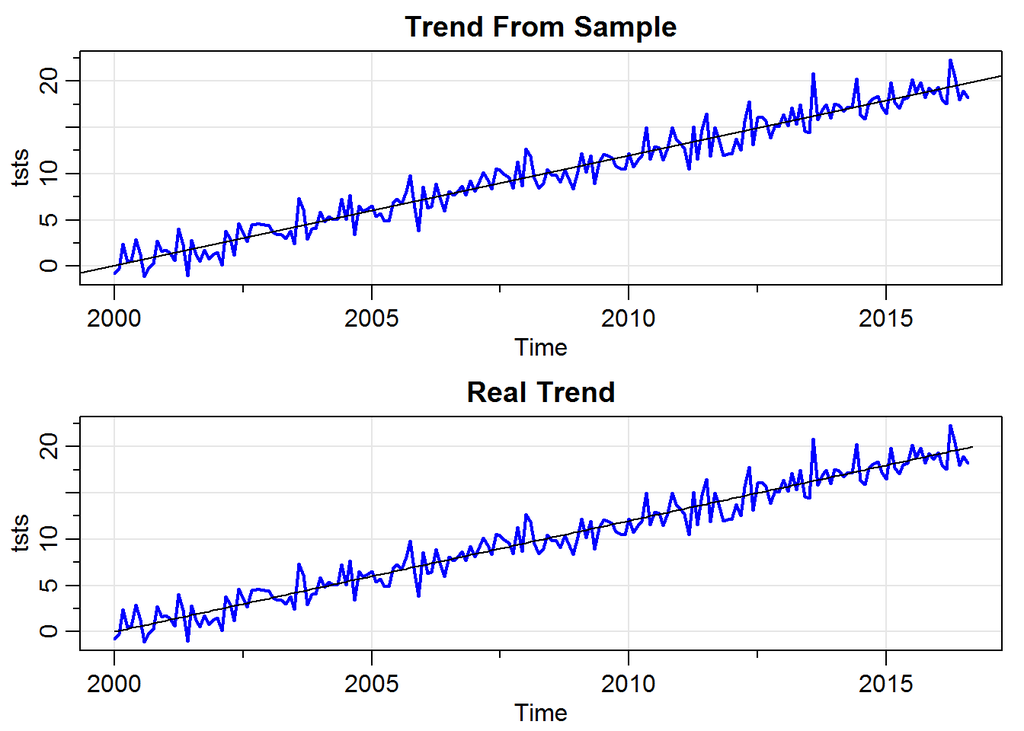

```r
fit <- lm(tsts~time(tsts))
par(mfrow=c(2,1))
tsplot(tsts, main="Trend From Sample", col=4, lwd=2)
abline(fit)           # add the fitted regression line to the plot
tsplot(tsts, main="Real Trend", col=4, lwd=2)
lines(ts(trend,start=c(2000,1),frequency = 12)) # add the real trend to the plot
```

```r
summary(fit)
```

```
##
## Call:
## lm(formula = tsts ~ time(tsts))
##
## Residuals:
##     Min      1Q  Median      3Q     Max
## -3.2846 -0.8823 -0.0893  0.8308  4.6648
##
## Coefficients:
##               Estimate Std. Error t value Pr(>|t|)
## (Intercept) -2.374e+03  3.942e+01  -60.21   <2e-16 ***
## time(tsts)   1.187e+00  1.963e-02   60.46   <2e-16 ***
## ---
## Signif. codes:  0 '***' 0.001 '**' 0.01 '*' 0.05 '.' 0.1 ' ' 1
##
## Residual standard error: 1.336 on 198 degrees of freedom
## Multiple R-squared:  0.9486, Adjusted R-squared:  0.9484
## F-statistic:  3656 on 1 and 198 DF,  p-value: < 2.2e-16
```

We can see that the predicted trend is very similar to the real one.  
The obtained value 1.187 is very close to the real value of 1.2 (0.1 for 12 months).

Once we remove the trend from the series we obtain the residuals, wich  
should be stationary.  
Since we already have the trend lets now calculate the ACF of the residuals.

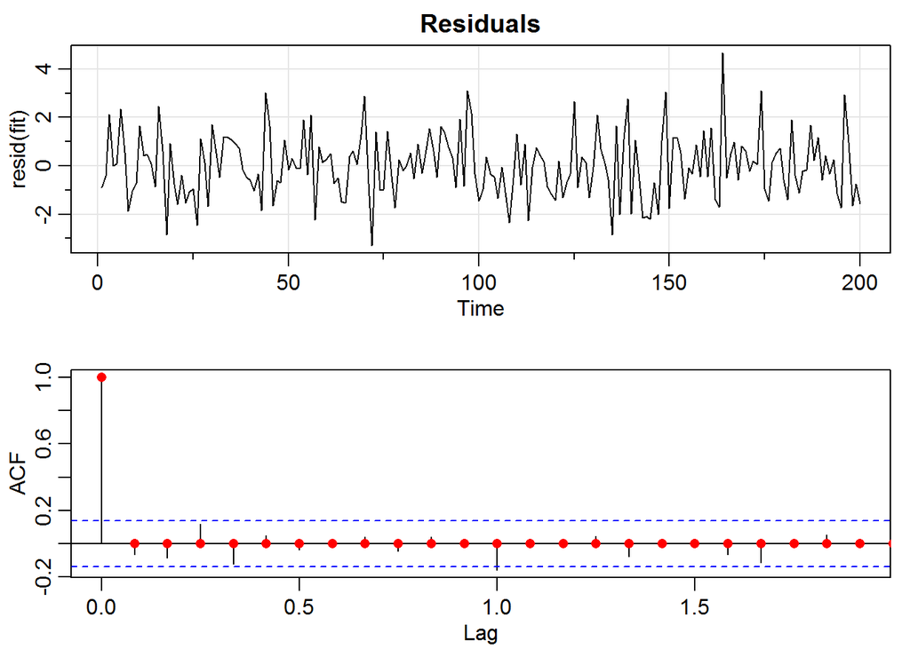

```r
par(mfrow=c(2,1))
tsplot(resid(fit), main = "Residuals")
acf(ts(resid(fit),frequency = 12))
points(x=seq(0,2,by=1/12),y=c(1,rep(0,24)),pch=16,col="red") #Values of model ACF
```

As we can see, once the trend is removed, the ACF of the time series closely  
follows the theoretical values, as we would expect from a trend stationary.  
The residuals should only be random noise, and it looks like it, but to be sure  
we will do a box test.

```r
Box.test(resid(fit))
```

```
##
##  Box-Pierce test
##
## data:  resid(fit)
## X-squared = 0.86229, df = 1, p-value = 0.3531
```

The box test gives a high p-value, so we conclude the values are not correlated  
and as such we can now conclude that the residuals are white noise.